# Practical ML course project

Monkey

Sep 2019

## Data reading

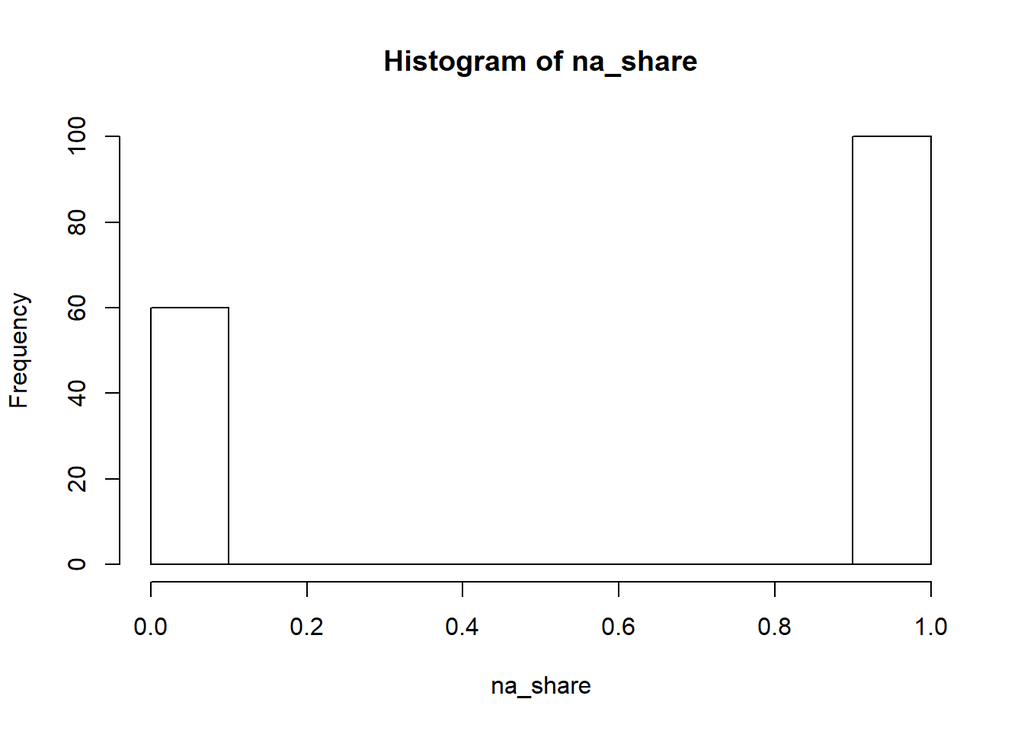

```r
#setting working directory
setwd("H:/BigOne/Root/R-Coursera/PracticalMachineLearinng/")
Sys.setlocale("LC_ALL","English")
if (!file.exists("pml-training.csv")){
download.file("https://d396qusza40orc.cloudfront.net/predmachlearn/pml-training.csv",
              destfile ="pml-training.csv" )
}
if (!file.exists("pml-testing.csv")){
download.file("https://d396qusza40orc.cloudfront.net/predmachlearn/pml-testing.csv",
              destfile ="pml-testing.csv" )
}
training = read.csv("pml-training.csv",na.strings = c("NA","","#DIV/0!"))
testing = read.csv("pml-testing.csv",na.strings = c("NA","","DIV/0!"))
library(magrittr)
library(data.table)
library(ggplot2)
library(GGally)
library(caret)
library(randomForest)
training %>% str

na.freq=function(x){
  y=x %>% is.na %>% sum
  y/length(x)
}

na_share=sapply(training, na.freq)
#seems like we have a bunch of variables with no or little data
hist(na_share)
```

```r
#get rid off columns with lots of NAs
subset_cols=names(training)[na_share<.5]
trainDT=training[,c(subset_cols)]
#net we will remove time and num window variables
#because they may be used to guess activity but actualy has no pridictive out of sample value
setDT(trainDT)
#the num_window is actualy more of a factor variable or id variable for particular exercise / measurement
trainDT=trainDT[,grep("time|window", names(trainDT)) := NULL]
trainDT$X = NULL
trainDT$user_name %<>% as.factor
testing$user_name %<>% factor(levels = levels(trainDT$user_name))
```

## Data transformations

After loading and looking through data we found that huge number of variables have no or almost no data. So we will build our model only on subset of varibles that where all observations are present. Also we will remove all variables with **time** or **window** in its name because they only give us information about observation sequence.

## Exploratory analysis

```r
#maybe we can see some group of variables
numcols=which(sapply(trainDT, is.numeric))
(cor(trainDT[,numcols,with=F])-diag(length(numcols))) %>% heatmap()
#meehhh nothing interesting # not gonna do pca anyway
```

[output not shown]

First we will explore how variables are distributed in different clases. Because we have 54 of them we will take some semi-random set of variables.

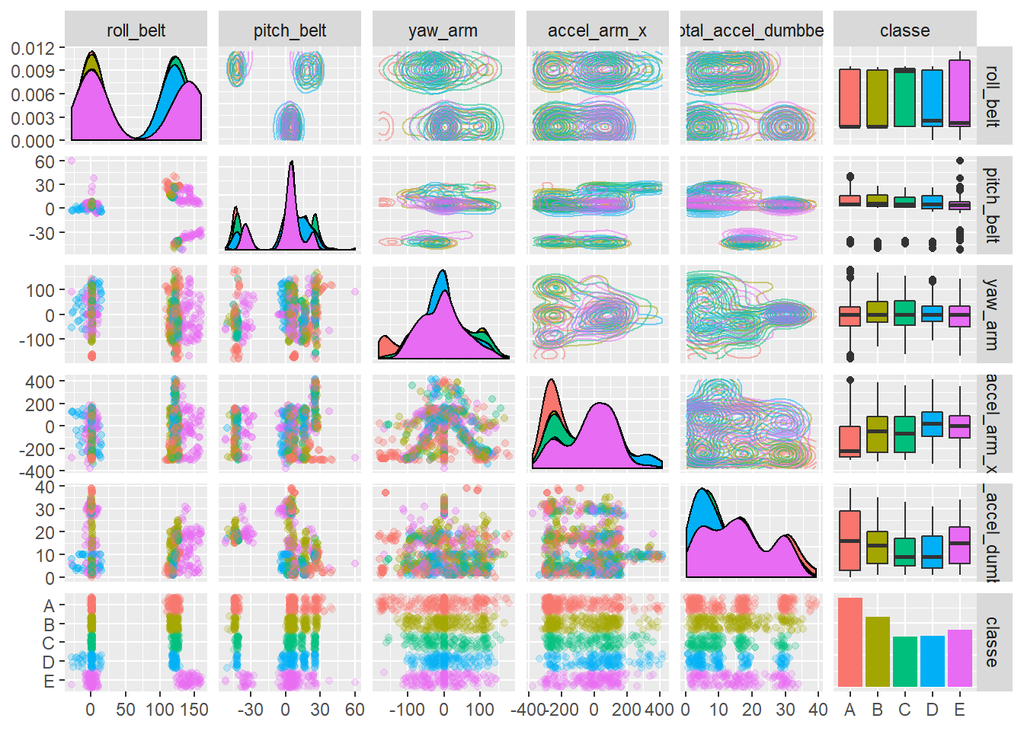

```r
set.seed(1)
exp_cols = names(trainDT)[c(2:3,sample(4:53,3),54)]
exp_i = sample(nrow(trainDT),1000)
#All data looks like that
ggpairs(data=trainDT[exp_i,exp_cols,with=F],
        mapping = aes(color=classe),
        upper = list(continuous = wrap("density", alpha = 0.5), combo = "box_no_facet"),
        lower = list(continuous = wrap("points", alpha = 0.3), combo = wrap("dot_no_facet", alpha = 0.2)))
```

What we can see is that variables have multiple tops in density plots. What also we can see that at least variances of some variables differ between classes(ex. **pitch_belt** or **roll_belt**). Before thinking about model we will look on same plot only for one person. Probably some of varience in plots may be due different persons measurements. Lets look on Carlitos measurements.

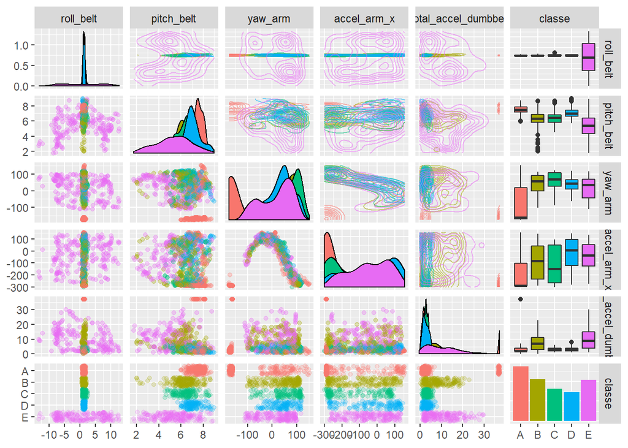

```r
#we know that there are 6 persons so there is 19k/6
exp_i_carlitos = sample(trainDT[,which(user_name=="carlitos")],1000)
#what we can see is tha
ggpairs(data=trainDT[exp_i_carlitos,exp_cols,with=F],
        mapping = aes(color=classe),
        upper = list(continuous = wrap("density", alpha = 0.5), combo = "box_no_facet"),
        lower = list(continuous = wrap("points", alpha = 0.3), combo = wrap("dot_no_facet", alpha = 0.2)))
```

What we can see is that given subset of variables became more bell-shaped. Even though covarience matrices between groups don’t appear the same. What we can do from here is to use decision trees(non parametic so more flexible) or quadratic linear discriminant analysis. For QDA rescaling variables on per person level may be a good idea. Lets look then on rescaled data.

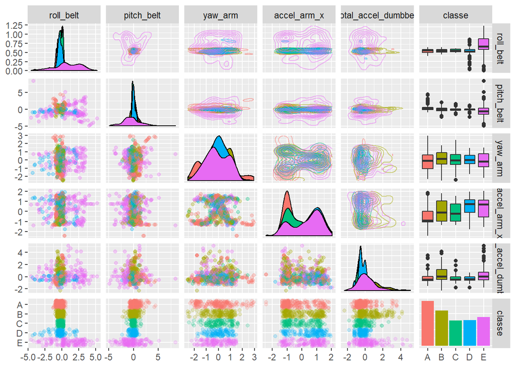

```r
# ok now lets look if we can preprocess our data to metigate personal differences.
# we will standertize all variable on per persona levels
# data frames below may by needed if we would predict testing data set
means_proc = trainDT[,lapply(.SD, mean),by=user_name,.SDcols=-c("classe")]
sd_proc = trainDT[,lapply(.SD, sd),by=user_name,.SDcols=-c("classe")]

#but to scale variables in trainDT we won't use them
cols=names(trainDT)[-c(1,54)]
trainDT_scaled=copy(trainDT)
for (j in names(trainDT_scaled) ){
if (trainDT_scaled[[j]] %>% is.integer) set(trainDT_scaled, j =j,value = as.numeric(trainDT_scaled[[j]]))
  }
trainDT_scaled[,(cols):=lapply(.SD,function(x) as.vector(scale(x))),by=user_name,.SDcols = cols]

#just in case check if scaling per person went ok
#plot(trainDT_scaled$roll_belt,trainDT$roll_belt)

#what we can see is that our scaling has made its job for given set of variables
ggpairs(data=trainDT_scaled[exp_i,exp_cols,with=F],
        mapping = aes(color=classe),
        upper = list(continuous = wrap("density", alpha = 0.5), combo = "box_no_facet"),
        lower = list(continuous = wrap("points", alpha = 0.3), combo = wrap("dot_no_facet", alpha = 0.2)))
```

Even though scaling helped to some degree. It came with another problem. There is no measurements for Jeremy on several variables even though for other people there are plenty of data.

```r
trainDT[user_name=="jeremy",.(roll_arm,pitch_arm,yaw_arm)] %>% summary()
```

```
##     roll_arm   pitch_arm    yaw_arm
##  Min.   :0   Min.   :0   Min.   :0
##  1st Qu.:0   1st Qu.:0   1st Qu.:0
##  Median :0   Median :0   Median :0
##  Mean   :0   Mean   :0   Mean   :0
##  3rd Qu.:0   3rd Qu.:0   3rd Qu.:0
##  Max.   :0   Max.   :0   Max.   :0
```

So we will stick with decision trees as our approach and random forest(*RF*) in particular. Another good news is that we don’t need data preprocessing for *RF*. One particular point about *RF* is that it uses OOB(out of bag) estimation for test errors. It makes cross validation unnecessary for this purpose. But we can use cross validation to pick better number of variables per tree.

## Training the model

```r
train_index = createDataPartition(trainDT$classe,p=.6,list=F)
trainingDT = trainDT[train_index,]
trainingDT_scaled = trainDT_scaled[train_index,]
#valDT here is actualy used as testing data. not confuse with another testing data size of 20.
valDT = trainDT[-train_index,]


ctrl = trainControl(method = "cv", number = 5)
mtryGrid=data.frame(mtry=c(2,4,10,20,30,50))

if (!file.exists("fitRF100cv.rds")){
  fitRF100cv = train(classe ~ .,data = trainingDT,
                   method="rf",ntree=100,
                   trainControl=ctrl,tuneGrid = mtryGrid)
  saveRDS(fitRF100cv,"fitRF100cv.rds")
} else {
  fitRF100cv = readRDS("fitRF100cv.rds")
}

fitRF100cv$results
```

```
##   mtry  Accuracy     Kappa  AccuracySD     KappaSD
## 1    2 0.9834476 0.9790475 0.002291736 0.002897336
## 2    4 0.9865050 0.9829202 0.002057996 0.002600485
## 3   10 0.9882779 0.9851645 0.002180454 0.002757691
## 4   20 0.9865722 0.9830056 0.002619912 0.003312385
## 5   30 0.9847106 0.9806495 0.002785879 0.003519690
## 6   50 0.9787867 0.9731510 0.003730914 0.004718727
```

```r
fitRF100cv$finalModel
```

```
##
## Call:
##  randomForest(x = x, y = y, ntree = 100, mtry = param$mtry, trainControl = ..2)
##                Type of random forest: classification
##                      Number of trees: 100
## No. of variables tried at each split: 10
##
##         OOB estimate of  error rate: 0.8%
## Confusion matrix:
##      A    B    C    D    E class.error
## A 3343    3    0    1    1 0.001493429
## B   18 2254    6    1    0 0.010969724
## C    0   22 2026    6    0 0.013631938
## D    0    0   26 1903    1 0.013989637
## E    0    0    4    5 2156 0.004157044
```

```r
confusionMatrix(predict(fitRF100cv,newdata = valDT),valDT$classe)
```

```
## Confusion Matrix and Statistics
##
##           Reference
## Prediction    A    B    C    D    E
##          A 2232    5    0    0    0
##          B    0 1512    1    0    0
##          C    0    1 1367    7    2
##          D    0    0    0 1279    0
##          E    0    0    0    0 1440
##
## Overall Statistics
##
##                Accuracy : 0.998
##                  95% CI : (0.9967, 0.9988)
##     No Information Rate : 0.2845
##     P-Value [Acc > NIR] : < 2.2e-16
##
##                   Kappa : 0.9974
##
##  Mcnemar's Test P-Value : NA
##
## Statistics by Class:
##
##                      Class: A Class: B Class: C Class: D Class: E
## Sensitivity            1.0000   0.9960   0.9993   0.9946   0.9986
## Specificity            0.9991   0.9998   0.9985   1.0000   1.0000
## Pos Pred Value         0.9978   0.9993   0.9927   1.0000   1.0000
## Neg Pred Value         1.0000   0.9991   0.9998   0.9989   0.9997
## Prevalence             0.2845   0.1935   0.1744   0.1639   0.1838
## Detection Rate         0.2845   0.1927   0.1742   0.1630   0.1835
## Detection Prevalence   0.2851   0.1928   0.1755   0.1630   0.1835
## Balanced Accuracy      0.9996   0.9979   0.9989   0.9973   0.9993
```

As has been said earlier *RF* uses OOB estimation for test error. The estimation in 0.8%. We can check if our model performs as well on validation set(or a testing set given the fact that it won’t be used for anything else). The accuracy on validation set is 0.998. Our estimation of test error seems good.  
As final tip we can watch which variables were most important.

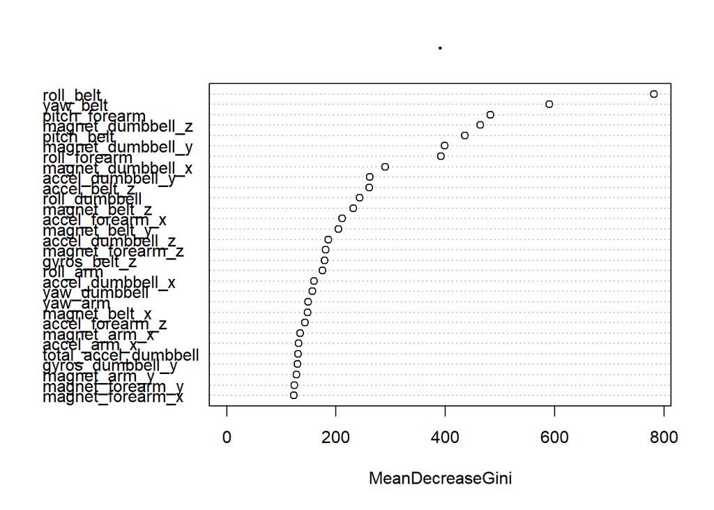

```r
#improtance
fitRF100cv$finalModel %>% varImpPlot()
```